# Lab09 - Multiple Regression in R

Jarad Niemi

2018-04-02

To follow along, use the lab09 code and make sure the following packages are installed:

- GGally
- tidyr

You can use the following code to perform the installation:

```r
install.packages(c("GGally","tidyr"))
```

Now load these and other packages

```r
library("dplyr")
```

```r
library("tidyr")
library("ggplot2")
library("GGally")
library("Sleuth3")
```

## Higher order terms

Consider the `case1001` data set.

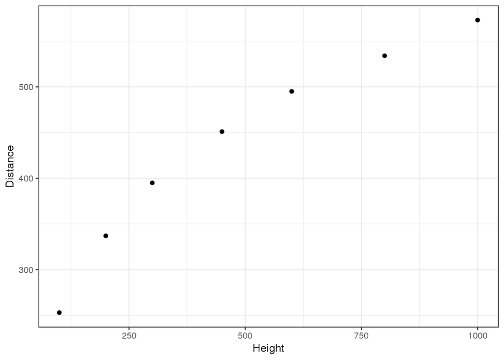

```r
ggplot(case1001, aes(Height, Distance)) +
  geom_point() + theme_bw()
```

There are a number of ways to run the cubic model.

```r
# First create the variables yourself
case1001_tmp <- case1001 %>%
  mutate(Height2 = Height * Height,
         Height3 = Height * Height2)

# Then run the regression
m1 <- lm(Distance ~ Height + Height2 + Height3, data = case1001_tmp)
```

I don’t prefer this method because

- it clutters your `data.frame` with unnecessary columns and
- it makes prediction harder

```r
new <- data.frame(Height = 500) %>%
  mutate(Height2 = Height * Height,  # Need to manually create the
         Height3 = Height * Height2) # quadratic and cubic terms
predict(m1, new)
```

```
##        1
## 470.6527
```

An alternative approach is to use a formula to construct the higher order terms. e.g.

```r
m2 <- lm(Distance ~ Height + I(Height^2) + I(Height^3), data = case1001) # or
m3 <- lm(Distance ~ poly(Height, 3, raw = TRUE),        data = case1001)
```

Now, your original `data.frame` is unchanged and your new `data.frame is simpler.

```r
new <- data.frame(Height = 500)
predict(m2, new) # or
```

```
##        1
## 470.6527
```

```r
predict(m3, new)
```

```
##        1
## 470.6527
```

## Additional explanatory variables

Run the following code to construct the longnosedace data

```r
# From http://www.biostathandbook.com/multipleregression.html
longnosedace <- structure(list(stream = structure(1:67, .Label = c("BASIN_RUN",
"BEAR_BR", "BEAR_CR", "BEAVER_DAM_CR", "BEAVER_RUN", "BENNETT_CR",
"BIG_BR", "BIG_ELK_CR", "BIG_PIPE_CR", "BLUE_LICK_RUN", "BROAD_RUN",
"BUFFALO_RUN", "BUSH_CR", "CABIN_JOHN_CR", "CARROLL_BR", "COLLIER_RUN",
"CONOWINGO_CR", "DEAD_RUN", "DEEP_RUN", "DEER_CR", "DORSEY_RUN",
"FALLS_RUN", "FISHING_CR", "FLINTSTONE_CR", "GREAT_SENECA_CR",
"GREENE_BR", "GUNPOWDER_FALLS", "HAINES_BR", "HAWLINGS_R", "HAY_MEADOW_BR",
"HERRINGTON_RUN", "HOLLANDS_BR", "ISRAEL_CR", "LIBERTY_RES",
"LITTLE_ANTIETAM_CR", "LITTLE_BEAR_CR", "LITTLE_CONOCOCHEAGUE_CR",
"LITTLE_DEER_CR", "LITTLE_FALLS", "LITTLE_GUNPOWDER_R", "LITTLE_HUNTING_CR",
"LITTLE_PAINT_BR", "MAINSTEM_PATUXENT_R", "MEADOW_BR", "MILL_CR",
"MORGAN_RUN", "MUDDY_BR", "MUDLICK_RUN", "NORTH_BR", "NORTH_BR_CASSELMAN_R",
"NORTHWEST_BR", "NORTHWEST_BR_ANACOSTIA_R", "OWENS_CR", "PATAPSCO_R",
"PINEY_BR", "PINEY_CR", "PINEY_RUN", "PRETTYBOY_BR", "RED_RUN",
"ROCK_CR", "SAVAGE_R", "SECOND_MINE_BR", "SENECA_CR", "SOUTH_BR_CASSELMAN_R",
"SOUTH_BR_PATAPSCO", "SOUTH_FORK_LINGANORE_CR", "TUSCARORA_CR"
), class = "factor"), count = c(13L, 12L, 54L, 19L, 37L, 2L,
72L, 164L, 18L, 1L, 53L, 16L, 32L, 21L, 23L, 18L, 112L, 25L,
5L, 26L, 8L, 15L, 11L, 11L, 87L, 33L, 22L, 98L, 1L, 5L, 1L, 38L,
30L, 12L, 24L, 6L, 15L, 38L, 84L, 3L, 18L, 63L, 239L, 234L, 6L,
76L, 25L, 8L, 23L, 16L, 6L, 100L, 80L, 28L, 48L, 18L, 36L, 19L,
32L, 3L, 106L, 62L, 23L, 2L, 26L, 20L, 38L), acreage = c(2528L,
3333L, 19611L, 3570L, 1722L, 583L, 4790L, 35971L, 25440L, 2217L,
1971L, 12620L, 19046L, 8612L, 3896L, 6298L, 27350L, 4145L, 1175L,
8297L, 7814L, 1745L, 5046L, 18943L, 8624L, 2225L, 12659L, 1967L,
1172L, 639L, 7056L, 1934L, 6260L, 424L, 3488L, 3330L, 2227L,
8115L, 1600L, 15305L, 7121L, 5794L, 8636L, 4803L, 1097L, 9765L,
4266L, 1507L, 3836L, 17419L, 8735L, 22550L, 9961L, 4706L, 4011L,
6949L, 11405L, 904L, 3332L, 575L, 29708L, 2511L, 18422L, 6311L,
1450L, 4106L, 10274L), do2 = c(9.6, 8.5, 8.3, 9.2, 8.1, 9.2,
9.4, 10.2, 7.5, 8.5, 11.9, 8.3, 8.3, 8.2, 10.4, 8.6, 8.5, 8.7,
7.7, 9.9, 6.8, 9.4, 7.6, 9.2, 8.6, 9.1, 9.7, 8.6, 8.3, 9.5, 6.4,
10.5, 9.5, 8.3, 9.3, 9.1, 6.8, 9.6, 10.2, 9.7, 9.5, 9.4, 8.4,
8.5, 8.3, 9.3, 8.9, 7.4, 8.3, 7.4, 8.2, 8.4, 8.6, 8.9, 8.3, 9.3,
9.2, 9.8, 8.4, 6.8, 7.7, 10.2, 9.9, 7.6, 7.9, 10, 9.3), maxdepth = c(80L,
83L, 96L, 56L, 43L, 51L, 91L, 81L, 120L, 46L, 56L, 37L, 120L,
103L, 105L, 42L, 65L, 51L, 57L, 60L, 160L, 48L, 109L, 50L, 78L,
41L, 65L, 50L, 73L, 26L, 60L, 85L, 133L, 62L, 44L, 67L, 54L,
110L, 56L, 85L, 58L, 34L, 150L, 93L, 53L, 130L, 68L, 51L, 121L,
48L, 63L, 107L, 79L, 61L, 52L, 100L, 70L, 39L, 73L, 33L, 73L,
60L, 45L, 46L, 60L, 96L, 90L), no3 = c(2.28, 5.34, 0.99, 5.44,
5.66, 2.26, 4.1, 3.2, 3.53, 1.2, 3.25, 0.61, 2.93, 1.57, 2.77,
0.26, 6.95, 0.34, 1.3, 5.26, 0.44, 2.19, 0.73, 0.25, 3.37, 2.3,
3.3, 7.71, 2.62, 3.53, 0.25, 2.34, 2.41, 3.49, 2.11, 0.81, 0.33,
3.4, 3.54, 2.6, 0.51, 1.19, 3.31, 5.01, 1.71, 4.38, 2.05, 0.84,
1.32, 0.29, 1.56, 1.41, 1.02, 4.06, 4.7, 4.57, 2.17, 6.81, 2.09,
2.47, 0.63, 4.17, 1.58, 0.64, 2.96, 2.62, 5.45), so4 = c(16.75,
7.74, 10.92, 16.53, 5.91, 8.81, 5.65, 17.53, 8.2, 10.85, 11.12,
18.87, 11.31, 16.09, 12.79, 17.63, 14.94, 44.93, 21.68, 6.36,
20.24, 10.27, 7.1, 14.21, 7.51, 9.72, 5.98, 26.44, 4.64, 4.46,
9.82, 11.44, 13.77, 5.82, 13.37, 8.16, 7.6, 9.22, 5.69, 6.96,
7.41, 12.27, 5.95, 10.98, 15.77, 5.74, 12.77, 16.3, 7.36, 2.5,
13.22, 14.45, 9.07, 9.9, 5.38, 17.84, 10.17, 9.2, 5.5, 7.61,
12.28, 10.75, 8.37, 21.16, 8.84, 5.45, 24.76), temp = c(15.3,
19.4, 19.5, 17, 19.3, 12.9, 16.7, 13.8, 13.7, 14.3, 22.2, 16.8,
18, 15, 18.4, 18.2, 24.1, 23, 21.8, 19.1, 22.6, 14.3, 19, 18.5,
21.3, 20.5, 18, 16.8, 20.5, 20.1, 24.5, 12, 21, 20.2, 24, 14.9,
24, 20.5, 19.5, 17.5, 16, 17.5, 18.1, 24.3, 13.1, 16.9, 17, 21,
18.5, 18, 20.8, 23, 21.8, 19.7, 18.9, 18.6, 23.6, 19.2, 17.7,
18, 21.4, 17.7, 20.1, 18.5, 18.6, 15.4, 15)), .Names = c("stream",
"count", "acreage", "do2", "maxdepth", "no3", "so4", "temp"), class = "data.frame", row.names = c(NA,
-67L))
```

Take a quick look at the data

```r
head(longnosedace)
```

```
##          stream count acreage do2 maxdepth  no3   so4 temp
## 1     BASIN_RUN    13    2528 9.6       80 2.28 16.75 15.3
## 2       BEAR_BR    12    3333 8.5       83 5.34  7.74 19.4
## 3       BEAR_CR    54   19611 8.3       96 0.99 10.92 19.5
## 4 BEAVER_DAM_CR    19    3570 9.2       56 5.44 16.53 17.0
## 5    BEAVER_RUN    37    1722 8.1       43 5.66  5.91 19.3
## 6    BENNETT_CR     2     583 9.2       51 2.26  8.81 12.9
```

```r
summary(longnosedace)
```

```
##            stream       count          acreage           do2
##  BASIN_RUN    : 1   Min.   :  1.0   Min.   :  424   Min.   : 6.400
##  BEAR_BR      : 1   1st Qu.: 12.0   1st Qu.: 2221   1st Qu.: 8.300
##  BEAR_CR      : 1   Median : 23.0   Median : 4790   Median : 8.600
##  BEAVER_DAM_CR: 1   Mean   : 39.1   Mean   : 7670   Mean   : 8.793
##  BEAVER_RUN   : 1   3rd Qu.: 43.0   3rd Qu.: 9250   3rd Qu.: 9.450
##  BENNETT_CR   : 1   Max.   :239.0   Max.   :35971   Max.   :11.900
##  (Other)      :61
##     maxdepth           no3             so4              temp
##  Min.   : 26.00   Min.   :0.250   Min.   : 2.500   Min.   :12.00
##  1st Qu.: 51.00   1st Qu.:1.195   1st Qu.: 7.385   1st Qu.:16.95
##  Median : 63.00   Median :2.340   Median :10.170   Median :18.60
##  Mean   : 72.42   Mean   :2.634   Mean   :11.612   Mean   :18.76
##  3rd Qu.: 90.50   3rd Qu.:3.530   3rd Qu.:14.330   3rd Qu.:20.65
##  Max.   :160.00   Max.   :7.710   Max.   :44.930   Max.   :24.50
##
```

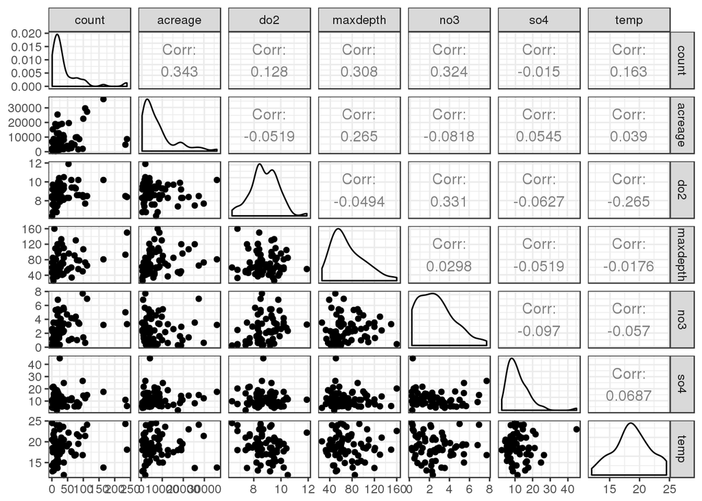

```r
ggpairs(longnosedace %>% select(-stream)) +
  theme_bw()
```

Adding additional explanatory variables is accomplished by separating the explanatory variables by `+`.

```r
m <- lm(sqrt(count) ~ no3 + maxdepth, data = longnosedace)
summary(m)
```

```
##
## Call:
## lm(formula = sqrt(count) ~ no3 + maxdepth, data = longnosedace)
##
## Residuals:
##     Min      1Q  Median      3Q     Max
## -4.4324 -1.8879 -0.5059  1.3957  7.7220
##
## Coefficients:
##             Estimate Std. Error t value Pr(>|t|)
## (Intercept)  1.48935    1.03036   1.445  0.15320
## no3          0.63531    0.19089   3.328  0.00145 **
## maxdepth     0.03121    0.01169   2.669  0.00962 **
## ---
## Signif. codes:  0 '***' 0.001 '**' 0.01 '*' 0.05 '.' 0.1 ' ' 1
##
## Residual standard error: 2.802 on 64 degrees of freedom
## Multiple R-squared:  0.2266, Adjusted R-squared:  0.2024
## F-statistic: 9.374 on 2 and 64 DF,  p-value: 0.0002688
```

## Interactions

Interactions can be added to a model by using a colon (:) between two explanatory variables, e.g.

```r
m1 <- lm(sqrt(count) ~ no3 + maxdepth + no3:maxdepth, data = longnosedace)
summary(m1)
```

```
##
## Call:
## lm(formula = sqrt(count) ~ no3 + maxdepth + no3:maxdepth, data = longnosedace)
##
## Residuals:
##     Min      1Q  Median      3Q     Max
## -4.5446 -1.8380 -0.5926  1.1360  6.9813
##
## Coefficients:
##               Estimate Std. Error t value Pr(>|t|)
## (Intercept)   3.095388   1.527579   2.026    0.047 *
## no3          -0.037301   0.511691  -0.073    0.942
## maxdepth      0.005705   0.021438   0.266    0.791
## no3:maxdepth  0.010467   0.007397   1.415    0.162
## ---
## Signif. codes:  0 '***' 0.001 '**' 0.01 '*' 0.05 '.' 0.1 ' ' 1
##
## Residual standard error: 2.78 on 63 degrees of freedom
## Multiple R-squared:  0.2504, Adjusted R-squared:  0.2147
## F-statistic: 7.015 on 3 and 63 DF,  p-value: 0.0003819
```

But because we have a convention of including main effects (lower order terms) whenever an interaction (higher order term) is included in the model, R provides a convenient way of including both the main effects as well as the interaction by using an asterisk (*).

```r
m2 <- lm(sqrt(count) ~ no3*maxdepth, data = longnosedace)
summary(m2)
```

```
##
## Call:
## lm(formula = sqrt(count) ~ no3 * maxdepth, data = longnosedace)
##
## Residuals:
##     Min      1Q  Median      3Q     Max
## -4.5446 -1.8380 -0.5926  1.1360  6.9813
##
## Coefficients:
##               Estimate Std. Error t value Pr(>|t|)
## (Intercept)   3.095388   1.527579   2.026    0.047 *
## no3          -0.037301   0.511691  -0.073    0.942
## maxdepth      0.005705   0.021438   0.266    0.791
## no3:maxdepth  0.010467   0.007397   1.415    0.162
## ---
## Signif. codes:  0 '***' 0.001 '**' 0.01 '*' 0.05 '.' 0.1 ' ' 1
##
## Residual standard error: 2.78 on 63 degrees of freedom
## Multiple R-squared:  0.2504, Adjusted R-squared:  0.2147
## F-statistic: 7.015 on 3 and 63 DF,  p-value: 0.0003819
```

Alternatively, you can use the caret symbol (^) and specifying what order interactions you want. For example `^2` will include all two-way interactions.

```r
m3 <- lm(sqrt(count) ~ (no3 + maxdepth)^2, data = longnosedace)
summary(m3)
```

```
##
## Call:
## lm(formula = sqrt(count) ~ (no3 + maxdepth)^2, data = longnosedace)
##
## Residuals:
##     Min      1Q  Median      3Q     Max
## -4.5446 -1.8380 -0.5926  1.1360  6.9813
##
## Coefficients:
##               Estimate Std. Error t value Pr(>|t|)
## (Intercept)   3.095388   1.527579   2.026    0.047 *
## no3          -0.037301   0.511691  -0.073    0.942
## maxdepth      0.005705   0.021438   0.266    0.791
## no3:maxdepth  0.010467   0.007397   1.415    0.162
## ---
## Signif. codes:  0 '***' 0.001 '**' 0.01 '*' 0.05 '.' 0.1 ' ' 1
##
## Residual standard error: 2.78 on 63 degrees of freedom
## Multiple R-squared:  0.2504, Adjusted R-squared:  0.2147
## F-statistic: 7.015 on 3 and 63 DF,  p-value: 0.0003819
```

You can find out more information by looking at

```r
?formula
```

## Activities

Practice these skills by taking a look at the data sets in the `Sleuth3` package.

```r
help(package="Sleuth3")
```

The data sets are organized by

1. textbook usage ([case] study or [ex]ample)
2. chapter, e.g. case0701 is chapter 7
3. number, e.g. case0701 is number 1.

The [Statistical Sleuth](http://www.statisticalsleuth.com/) 3rd ed by Ramsey and Schafer begins discussing regression in Chapter 7 (although ANOVA is discussed in Chapter 5). Thus, data sets in Chapters 5 through 14 are relevant for exploration. When you get a new data set ask yourself these questions in this order

1. What is the response variable?
2. How many explanatory variables are there?
3. Is the explanatory variable continuous or categorical?
4. How many levels does each categorical explanatory variable have?